# 5.2_decay_analysis_II

## 5.2 衰变实验的数据分析I -重离子和衰变事件的关联

数据：sort.root (按照上一次课件的描述生成root文件）

TTree Branch:

- timestamp, xstrip, ystrip, de
  - //de- dssd front energy
- me
  - //mwpc energy, me<0 when no dssd signal

#### alpha sepctrum:

[figure not shown]

```python
TCanvas *c1=new TCanvas("c1","c1");
TFile *fin=new TFile("sort1.root");
TTree *tree=(TTree*)fin->Get("tree");
tree->Print();
ULong64_t timestamp;
Int_t xstrip,ystrip;
Float_t me,de;
tree->SetBranchAddress("timestamp",&timestamp);
tree->SetBranchAddress("xstrip",&xstrip);
tree->SetBranchAddress("ystrip",&ystrip);
tree->SetBranchAddress("de",&de);
tree->SetBranchAddress("me",&me);
```

```
*Tree    :tree      : sorted events                                          *
*Entries :   107136 : Total =         2580874 bytes  File  Size =    1454832 *
*        :          : Tree compression factor =   1.77                       *
*Br    0 :timestamp : timestamp/l                                            *
*Entries :   107136 : Total  Size=     860009 bytes  File Size  =     544219 *
*Baskets :       27 : Basket Size=      32000 bytes  Compression=   1.58     *
*............................................................................*
*Br    1 :me        : me/F                                                   *
*Entries :   107136 : Total  Size=     430083 bytes  File Size  =     246434 *
*Baskets :       14 : Basket Size=      32000 bytes  Compression=   1.74     *
*............................................................................*
*Br    2 :de        : de/F                                                   *
*Entries :   107136 : Total  Size=     430083 bytes  File Size  =     379997 *
*Baskets :       14 : Basket Size=      32000 bytes  Compression=   1.13     *
*............................................................................*
*Br    3 :xstrip    : xstrip/I                                               *
*Entries :   107136 : Total  Size=     430155 bytes  File Size  =     133106 *
*Baskets :       14 : Basket Size=      32000 bytes  Compression=   3.23     *
*............................................................................*
*Br    4 :ystrip    : ystrip/I                                               *
*Entries :   107136 : Total  Size=     430155 bytes  File Size  =     149610 *
*Baskets :       14 : Basket Size=      32000 bytes  Compression=   2.87     *
*............................................................................*
```

```python
//tree->Scan("xstrip:ystrip:timestamp:me","","colsize=30",100,10000);
```

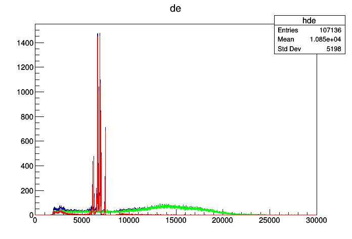

```
4172
```

```python
tree->Draw("de>>hde(3000,0,30000)");//all
tree->Draw("de>>hdem(3000,0,30000)","me>0");//coincide with mwpc
tree->Draw("de>>hdenm(3000,0,30000)","me<0");//mwpc veto
TH1F *hde, *hdem, *hdenm;
hde=(TH1F*)gROOT->FindObject("hde");
hdem=(TH1F*)gROOT->FindObject("hdem");
hdenm=(TH1F*)gROOT->FindObject("hdenm");
hde->Draw();
hdem->SetLineColor(kGreen);
hdenm->SetLineColor(kRed);
hdem->Draw("same");
hdenm->Draw("same");
c1->Draw();
cout<<hdem->Integral(600,750)<<endl;
```

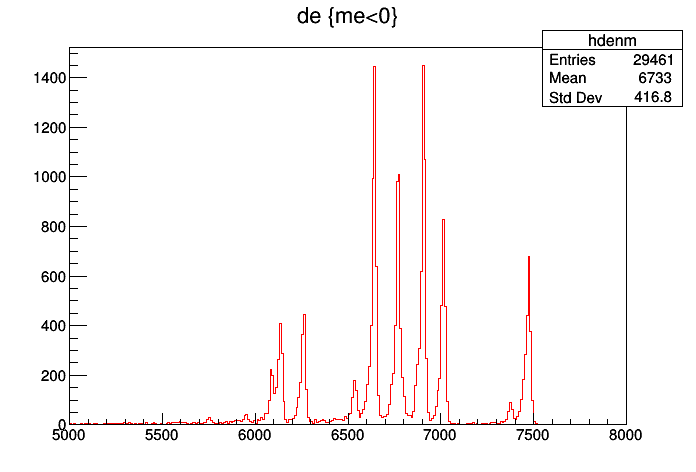

```python
hdenm->GetXaxis()->SetRangeUser(5000,8000);
hdenm->Draw();
c1->Draw();
```

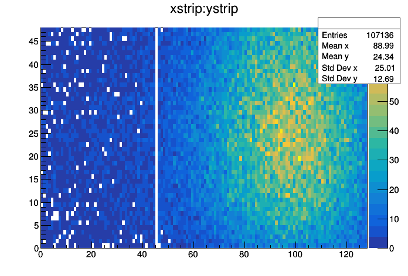

```python
tree->Draw("xstrip:ystrip>>(128,0,128,48,0,48)","","colz");
c1->SetLogy(0);
c1->SetLogz(0);
c1->Draw();
```

## 按照mwpc上的能量对事件进行分类

- 重离子(Implantation) me>0
- 衰变粒子(Decay) me<0

```python
struct dssd
{
    Float_t energy;
    Int_t xstrip,ystrip;
};
dssd ds;
multimap<ULong64_t, dssd> mapimp, mapdec;//implantaion, decay

Long64_t nentries = tree->GetEntriesFast();
for (Long64_t jentry=0; jentry<nentries;jentry++) {
    tree->GetEntry(jentry);
        ds.energy = de;
        ds.xstrip = xstrip;
        ds.ystrip = ystrip;
    if(me>0) mapimp.insert(pair<ULong64_t,dssd>(timestamp,ds));
    else mapdec.insert(pair<ULong64_t,dssd>(timestamp,ds));
}
cout<<"The number of implantation/decay : "<<mapimp.size()<<"  "<<mapdec.size()<<endl;
```

```
The number of implantation/decay : 77675  29461
```

## 重离子与衰变事件的关联

- 一般来说束流在DSSD上有着很宽的位置分布(通过调束，使得束流在注入探测器上有着较宽的分布)，且DSSD的每个pixel面积很小，可以认为在重离子强度不高时，重离子注入到某一颗粒后在一段不长的时间范围内(称为衰变时间窗)，该颗粒上发生的衰变事件都是由该注入核引起的。换句话说，可将DSSD探测器看成 $x \times y$ 个独立的探测单元，每个单元在衰变时间窗内只有一个重离子注入，并发生衰变。参数：ht,hx,hy; bt,be,bx,by

[figure not shown]

### 时间关联

- 当入射束流强度较低时(图.a)，在衰变时间窗内注入和衰变事件之间存在关联，时间差$\delta t=bt-ht$服从指数衰减分布。
  - 在衰变时间窗内，关联事件(注入时间，衰变时间)为
    - 1.（ht1,bt1）
    - 1. (ht2,bt2)
    - 1. (ht3,bt3)
    - 1. (ht4,bt4)
- 当入射束流强度较高时，在衰变时间窗内(图中箭头长度以内)发生的衰变事件可能不是来源于上一个注入的重离子的衰变，而是由更早的时间注入的其他重离子的衰变引起的(图.b)。这些事件之间不存在关联关系，此时其时间差 $\delta t=bt-ht$，服从均匀分布。对于衰变时间窗内的关联事件，其$\delta t=bt-ht$服从指数衰减分布。这两种类型事件是不可区分的。
  - 在衰变时间窗内，关联事件(注入时间，衰变时间)为
    - 1. (ht1,bt1）
    - 1. (ht2,bt2)
    - 1. (ht3,bt2),(ht3,bt3)
    - 1. (ht5,bt4),(ht5,bt5)
    - 1. (ht6,bt6)
- 上述将不同时刻发生的注入和衰变事件关联起来的方法称为position-time correlation for implantation and decay events。
  - 事件中包含不关联事件的贡献，这部分本底需要减掉。

### 位置关联条件

- 重离子和衰变事件在同一个颗粒的条件为:hx==bx && hy==by, hz==bz(当粒子注入到多个dssd时);
- 为了增加探测效率(部分beta粒子会散射到周围的颗粒上)，有时需要将注入和衰变事件的位置关联范围变大，如要求:abs(hx-bx)<2 && abs(hx-bx)<2;

## 在$\Delta x=0,\Delta y=0$ 和 $\Delta x=\pm 1, \Delta y=\pm1 $ 上寻找关联事件

```python
ULong64_t twindow = 20000000000;//20s
TH2F *hedt=new TH2F("hedt","decayenergy vs decaytime in the same pixiel",200,0,2e10,300,5000,8000);
TH2F *hedt1=new TH2F("hedt1","decayenergy vs decaytime with deltaXY=+/-1",200,0,2e10,300,5000,8000);
for(auto ia=mapimp.begin(); ia!=mapimp.end();ia++) {
     auto ib=mapdec.lower_bound(ia->first);
     for(auto ic=ib; ic!=mapdec.end();ic++) {
        if(ic->first >= ia->first + twindow) break;
        Int_t delx=abs(ic->second.xstrip-ia->second.xstrip);
        Int_t dely=abs(ic->second.ystrip-ia->second.ystrip);
        if(delx>1 || dely>1) continue; //
        Long64_t decaytime = (ic->first - ia->first);
        if(delx==0 && dely==0) hedt->Fill(decaytime,ic->second.energy);//same pixel (0,0)
        else hedt1->Fill(decaytime,ic->second.energy);//inside 3x3, exclude (0,0)
    }
}
```

### Heavy ion and decay correlation in the same pixel $\Delta x=0,\Delta y=0$

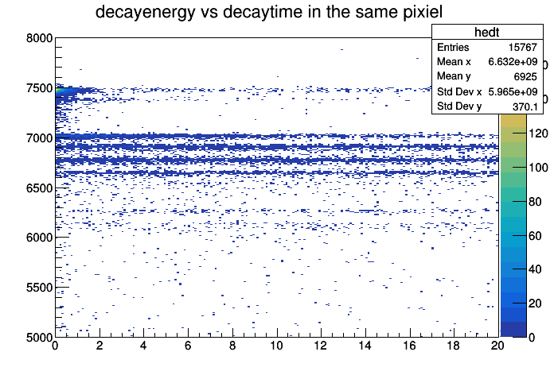

```python
c1->Clear();
hedt->Draw("colz");
c1->Draw();
```

### Heavy ion and decay correlation with $\Delta x=\pm 1,\Delta y=\pm 1$

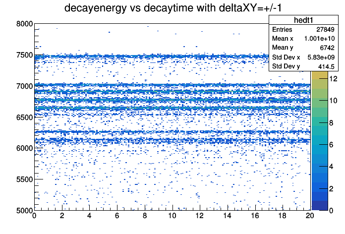

```python
c1->Clear();
hedt1->Draw("colz");
c1->Draw();
```

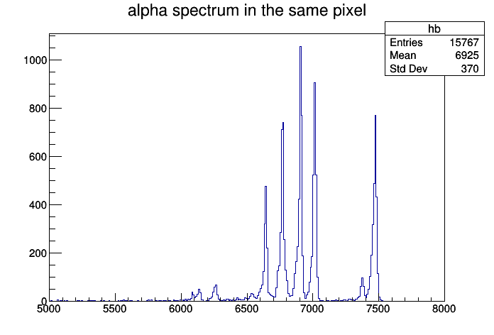

```python
TH1F *hb=(TH1F*)hedt->ProjectionY("hb");
hb->SetTitle("alpha spectrum in the same pixel");
hb->Draw();
c1->Draw();
```

### $^{211}Ac$的衰变时间分布

- 指数+均匀分布！

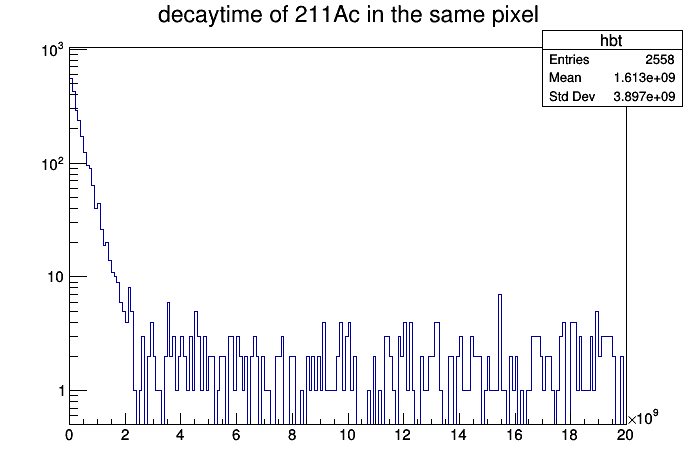

```python
Int_t bin1=hedt->GetYaxis()->FindBin(7400);
Int_t bin2=hedt->GetYaxis()->FindBin(7600);
TH1F *hbt=(TH1F*)hedt->ProjectionX("hbt",bin1,bin2);
hbt->SetTitle("decaytime of 211Ac in the same pixel");
gPad->SetLogy();
hbt->Draw();
c1->Draw();
```

## 衰变时间分布 $\Delta x=\pm 1,\Delta y=\pm 1$

- 几乎为均匀分布，表明$\pm1$的范围，注入粒子和衰变几乎没有关联

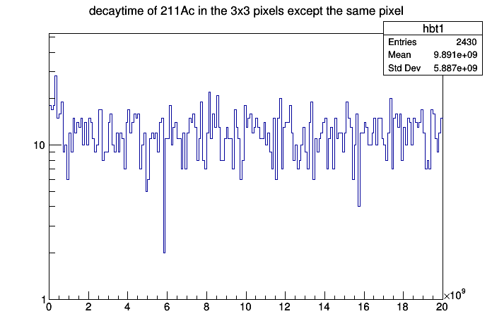

```python
Int_t bin11=hedt->GetYaxis()->FindBin(7400);
Int_t bin12=hedt->GetYaxis()->FindBin(7600);
TH1F *hbt1=(TH1F*)hedt1->ProjectionX("hbt1",bin11,bin12);
hbt1->SetTitle("decaytime of 211Ac in the 3x3 pixels except the same pixel");
gPad->SetLogy();
hbt1->Draw();
c1->Draw();
```

### 从半衰期曲线的对比看，关联主要在相同的颗粒上, 相同颗粒外几乎没有关联粒子。

- 对不同能量，不同类型的粒子，由于在探测器中的射程和散射程度的不同，关联的位置范围都有可能不同。
  - 应进行上述检验确定合理的位置关联范围。

## 减本底的方法

- 衰变曲线中有其他不关联事件形成的均匀分布的本底平台。

可选用两种方法之一

- 1. 大于5个半衰期之后的平台本底
- 1. 生成负时间本底

## 减去5个半衰期以后的平台本底

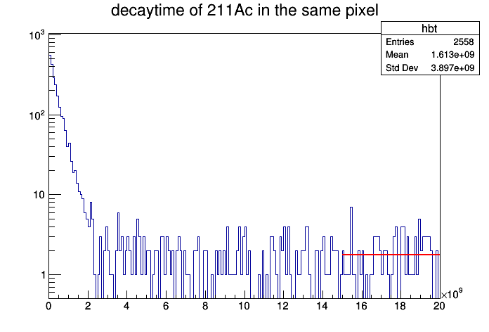

```
 FCN=32.4205 FROM MIGRAD    STATUS=CONVERGED      53 CALLS          54 TOTAL
                     EDM=6.37252e-07    STRATEGY= 1      ERROR MATRIX ACCURATE
  EXT PARAMETER                                   STEP         FIRST
  NO.   NAME      VALUE            ERROR          SIZE      DERIVATIVE
   1  p0           1.77985e+00   1.88664e-01   7.38324e-04  -4.23124e-03
                               ERR DEF= 0.5
```

```python
TF1 *fp01= new TF1("fp01","pol0",1.5e10,2e10);
hbt->Fit(fp01,"LR");
Double_t p01=fp01->GetParameter(0);
c1->SetLogy();
c1->Draw();
```

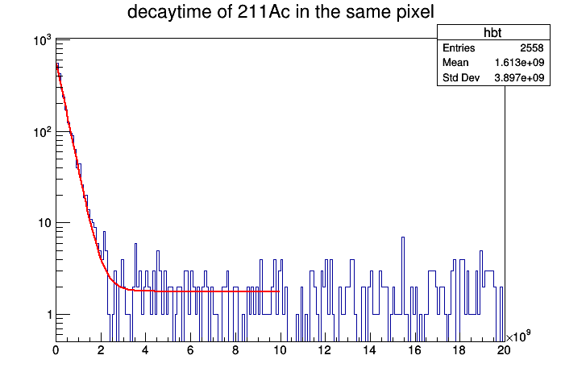

```
 FCN=47.5463 FROM MIGRAD    STATUS=CONVERGED     101 CALLS         102 TOTAL
                     EDM=3.23828e-08    STRATEGY= 1  ERROR MATRIX UNCERTAINTY   1.7 per cent
  EXT PARAMETER                                   STEP         FIRST
  NO.   NAME      VALUE            ERROR          SIZE      DERIVATIVE
   1  p0           1.77985e+00     fixed
   2  p1           6.16491e+02   1.97210e+01  -3.74906e-02  -1.17576e-05
   3  p2           2.49149e+08   6.06795e+06   2.72209e+04  -8.10062e-11

half-life of 211Ac is 249.149 +/- 6.06795 ms
```

```python
TF1 *fdecay1= new TF1("fdecay1","[0]+[1]*TMath::Exp(-x*TMath::Log(2.)/[2])",1,1e10);
fdecay1->FixParameter(0,p01);
fdecay1->SetParameter(2,1e8);
hbt->Fit(fdecay1,"R");
cout<<endl;
cout<<"half-life of 211Ac is "<<fdecay1->GetParameter(2)/1e6<<" +/- "<<fdecay1->GetParError(2)/1e6<<" ms"<<endl;
c1->SetLogy();
c1->Draw();
```

## 减负时间本底

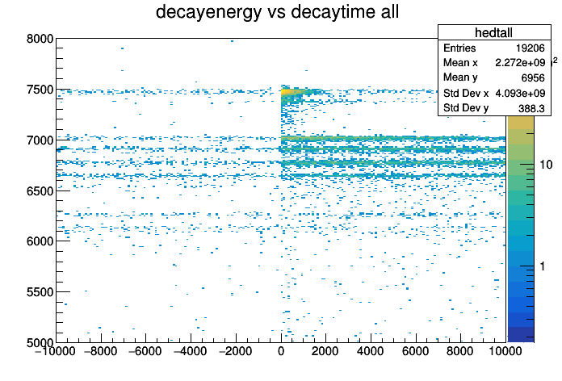

```python
twindow = 20000000000;//20s
TH2F *hedtall=new TH2F("hedtall","decayenergy vs decaytime all ",200,-1e10,1e10,300,5000,8000);
TH2F *hedtpos=new TH2F("hedtpos","decayenergy vs decaytime positive time",200,0,1e10,300,5000,8000);
TH2F *hedtneg=new TH2F("hedtneg","decayenergy vs decaytime negative time",200,0,1e10,300,5000,8000);
TH2F *hedtsub=new TH2F("hedtsub","decayenergy vs decaytime negative time",200,0,1e10,300,5000,8000);
for(auto ia=mapimp.begin(); ia!=mapimp.end();ia++) {
     auto ib=mapdec.lower_bound(ia->first-twindow);
     for(auto ic=ib; ic!=mapdec.end();ic++) {
        if(ic->first >= ia->first + twindow) break;
        if(abs(ic->second.xstrip-ia->second.xstrip)>0) continue;
        if(abs(ic->second.ystrip-ia->second.ystrip)>0) continue;
        Long64_t decaytime = ic->first - ia->first;
        hedtall->Fill(decaytime,ic->second.energy);
        if(decaytime>0) hedtpos->Fill(decaytime,ic->second.energy);
        else hedtneg->Fill(-decaytime,ic->second.energy);
    }
}
hedtall->Draw("colz");
c1->SetLogy(0);
c1->SetLogz();
c1->Draw();
```

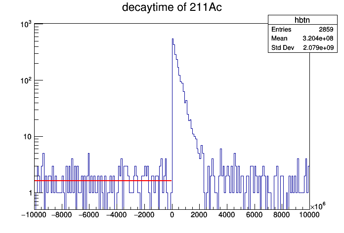

```
 FCN=49.8552 FROM MIGRAD    STATUS=CONVERGED      50 CALLS          51 TOTAL
                     EDM=3.38411e-07    STRATEGY= 1      ERROR MATRIX ACCURATE
  EXT PARAMETER                                   STEP         FIRST
  NO.   NAME      VALUE            ERROR          SIZE      DERIVATIVE
   1  p0           1.60993e+00   1.26880e-01   6.15582e-04  -4.58490e-03
                               ERR DEF= 0.5
```

```python
hedtall->GetYaxis()->SetRangeUser(7400,7600);
TH1F *hbtn=(TH1F*)hedtall->ProjectionX("hbtn");
hbtn->SetTitle("decaytime of 211Ac");
TF1 *fp0= new TF1("fp0","pol0",-1e10,0);
hbtn->Fit(fp0,"RL");
Double_t p0=fp0->GetParameter(0);
c1->SetLogy();
c1->Draw();
```

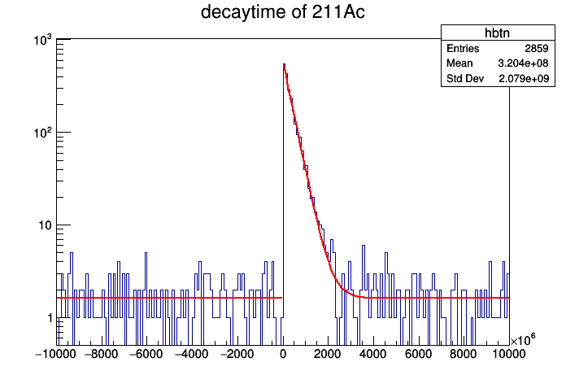

```
 FCN=51.5659 FROM MIGRAD    STATUS=CONVERGED     170 CALLS         171 TOTAL
                     EDM=1.04209e-08    STRATEGY= 1      ERROR MATRIX ACCURATE
  EXT PARAMETER                                   STEP         FIRST
  NO.   NAME      VALUE            ERROR          SIZE      DERIVATIVE
   1  p0           1.60993e+00     fixed
   2  p1           6.08523e+02   1.89192e+01   6.49125e-02   2.55573e-06
   3  p2           2.53575e+08   5.90993e+06   1.20914e+02  -1.03949e-11
                               ERR DEF= 0.5

half-life of 211Ac is 253.575 +/- 5.90993 ms
```

```python
TF1 *fdecay= new TF1("fdecay","[0]+[1]*TMath::Exp(-x*TMath::Log(2.)/[2])",1,1e10);
fdecay->FixParameter(0,p0);
fdecay->SetParameter(2,1e8);
hbtn->Fit(fdecay,"RL");
fp0->Draw("same");
cout<<endl;
cout<<"half-life of 211Ac is "<<fdecay->GetParameter(2)/1e6<<" +/- "<<fdecay->GetParError(2)/1e6<<" ms"<<endl;
c1->SetLogy();
c1->Draw();
```

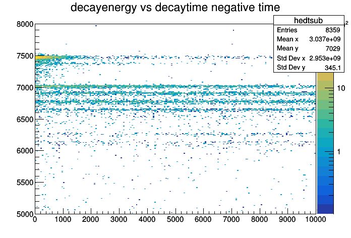

```python
hedtsub->Add(hedtpos,hedtneg,1,-1);
hedtsub->Draw("colz");
c1->SetLogy(0);
c1->Draw();
```

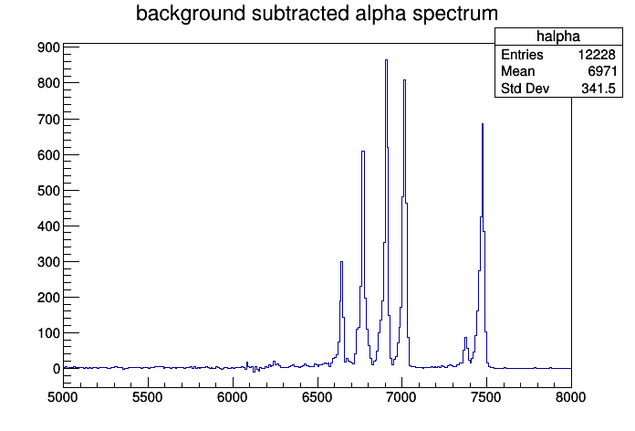

```python
TH1F *halpha=(TH1F*)hedtsub->ProjectionY("halpha");
halpha->SetTitle("background subtracted alpha spectrum");
halpha->Draw();
c1->SetLogy(0);
c1->Draw();
```

#### 对比前后三幅alpha能谱中7450keV(211Ac) 峰的计数，减完本底后的峰计数与原先的峰的计数类似。

## 寻找下一级衰变事件

[figure not shown]

### 下一级衰变事件的条件：$ bt[0]-ht<700ms$ , $ bt[1]-bt[0]<19s$

```python
twindow = 20000000000;//20s
TH2F *hbe2=new TH2F("hbe2","de_0:de_2",200,6000,8000,200,6000,8000);
TH1F *ht2=new TH1F("ht2","decay time of daughter",200,0,2e10);
for(auto ia=mapimp.begin(); ia!=mapimp.end();ia++) {
     ULong64_t ht=ia->first;
     auto ib=mapdec.lower_bound(ia->first);
     Double_t be[10];
     Long64_t bt[10];
     int bhit=0;
     for(auto ic=ib; ic!=mapdec.end();ic++) {
        if(ic->first >= ia->first + twindow) break;
        Int_t delx=abs(ic->second.xstrip-ia->second.xstrip);
        Int_t dely=abs(ic->second.ystrip-ia->second.ystrip);
        if(delx!=0 || dely!=0) continue; //
        be[bhit]=ic->second.energy;
        bt[bhit]=ic->first;
        bhit++;
        if(bhit>10) break;
    }
    if(bhit>1 && bt[0]-ht<700000000 && bt[1]-bt[0]<19000000000) {
        hbe2->Fill(be[0],be[1]);
        ht2->Fill(bt[1]-bt[0]);
    }
}
```

### 母核α-子核α能量关联图，包含逃逸事件

- 可以看到$^{207}Fr$的 6767keV的$\alpha$与$^{211}Ac$的 7477keV的$\alpha$关联

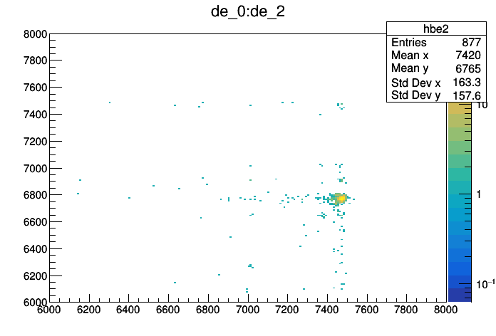

```python
hbe2->Draw("colz");
c1->SetLogz();
c1->Draw();
```

### 子核衰变时间谱

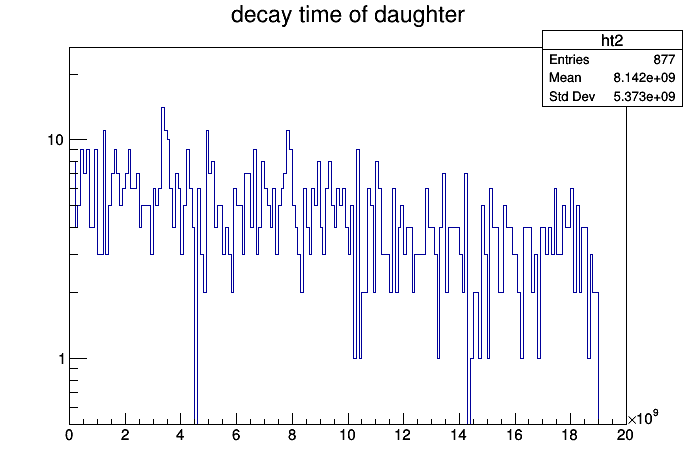

```python
ht2->Draw();
gPad->SetLogy();
c1->Draw();
```

### 通过alpha衰变链鉴别新核素

- 求多级衰变链中，每一级前(previous)后(next)衰变的alpha能量之间的关联，以及每一级衰变时间分布
- 从衰变链下端(时间长）的已知核向上端(时间短)推，最终确定未知衰变核的属性($A_N=A_p+4，Z_N=Z_p+2$)

```python
!jupyter nbconvert 5.2_decay_analysis_II.ipynb --to html
```

```
[NbConvertApp] Converting notebook 5.2_decay_analysis_II.ipynb to html

[NbConvertApp] Writing 685593 bytes to 5.2_decay_analysis_II.html
```